# tø uge 2

2025-01-30

Apply this transformation to the data, and then com- pute the mean $x̃$ and the median $m̃$ of the transformed data

question a:
$$\text{ Is}\,\, f (x) =
x̃?$$
question b:
$$\text{Is} f ( m )
= m̃?$$

```r
#we write up the data
x=c(1,2,4,5,6,8,11)
#calculate the transformed data
fx=sqrt(x)
# find the mean for the data
xb=mean(x)
#then the mean of the transformation
mean(fx)
```

```
## [1] 2.177832
```

```r
#then f of the mean
sqrt(xb)
```

```
## [1] 2.299068
```

```r
#now we do the exactly the same but for the median
m=median(x)
median(fx)
```

```
## [1] 2.236068
```

```r
sqrt(m)
```

```
## [1] 2.236068
```

Let x and m denote the mean and median, respectively, of
$$x_1 < x_2 < · · · < x_n$$
Let f be a real-valued function.

1. Is f(x) the mean off
   $$f(x_1),f(x_2),...,f(x_n)$$
   ? no simply look at the last exercise
2. Is f(m) the median off f(x1),f(x2),…,f(xn)? try $x=(x_1,x_2)=(1,2)$ $f=x^2$ not equal
3. Are there any conditions that would ensure that f (x) is the mean of the transformed data? liniarity of f or no variance in x
4. Are there any conditions that would ensure that f (m) is the median of the transformed data?

liniarity of f or no variance in x or f order preserving and n uneven

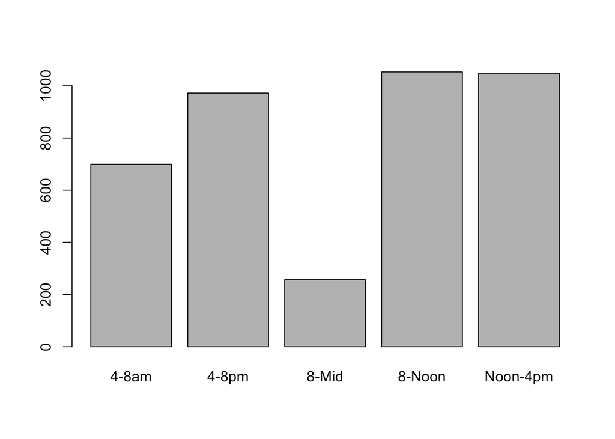

```r
s=table(FlightDelays$DepartTime)
barplot(s)
```

```r
tab <- table(FlightDelays$Day,FlightDelays$Delayed30)
prop.table(tab,1)
```

```
##
##               No        Yes
##   Fri 0.77394035 0.22605965
##   Mon 0.90317460 0.09682540
##   Sat 0.89624724 0.10375276
##   Sun 0.92014519 0.07985481
##   Thu 0.76678445 0.23321555
##   Tue 0.85191083 0.14808917
##   Wed 0.86524823 0.13475177
```

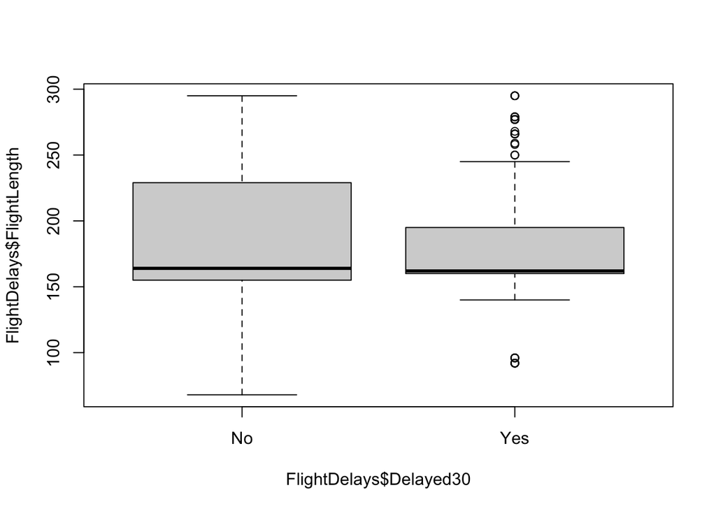

```r
boxplot(FlightDelays$FlightLength~FlightDelays$Delayed30)
```

opgave 2.4,d vi ser at hvis flyet er forsiket er der en støøre chance for at det er en medium længde flyvetur men også mange flere outliers, jeg ville kke drage nogle konklutioner

```r
par(mfrow=c(1,2))
tab <- table(Recidivism$Recid)
barplot(tab)
prop.table(tab)
```

```
##
##        No       Yes
## 0.6835859 0.3164141
```

```r
tab2 <-table(Recidivism$Age25,Recidivism$Recid)
prop.table(tab2,1)
```

```
##
##                   No       Yes
##   Over 25  0.6942333 0.3057667
##   Under 25 0.6350341 0.3649659
```

[figure not shown]

wee seee that about 30,6% of offenders over 25 go back to prison while about 36.5% of under 25 offenders go back

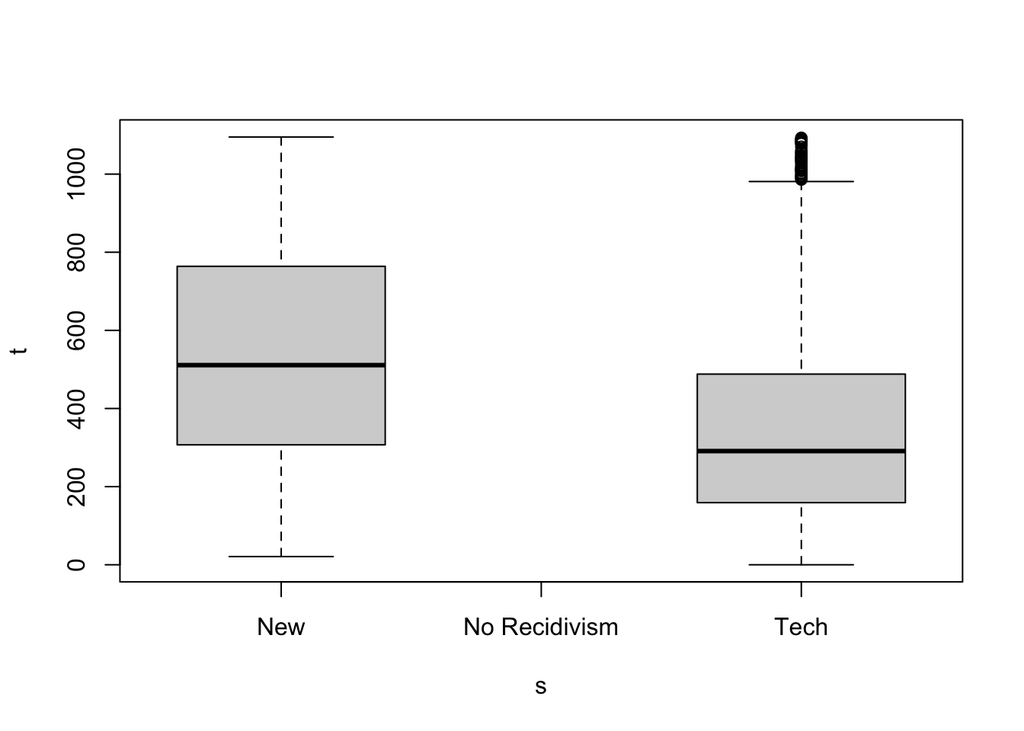

```r
t=Recidivism$Days
s=Recidivism$Type
boxplot(t~s)
```

the median reeviction time is lover for tech crimes . all quantiles are lover for the tech crime type

```r
quantile(Recidivism$Days,na.rm=TRUE)
```

```
##   0%  25%  50%  75% 100%
##    0  241  418  687 1095
```

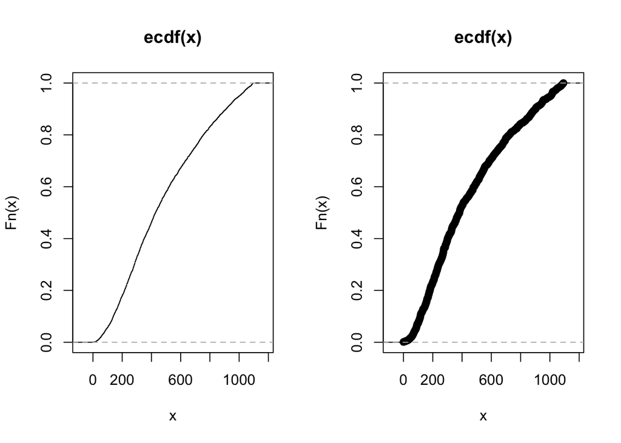

```r
par(mfrow=c(1,2))
over25 <-subset(Recidivism, Age25== "Over 25")
under25 <- subset(Recidivism,Age25== "Under 25")

plot.ecdf(over25$Days)
plot.ecdf(under25$Days)
```

opgave 1.26

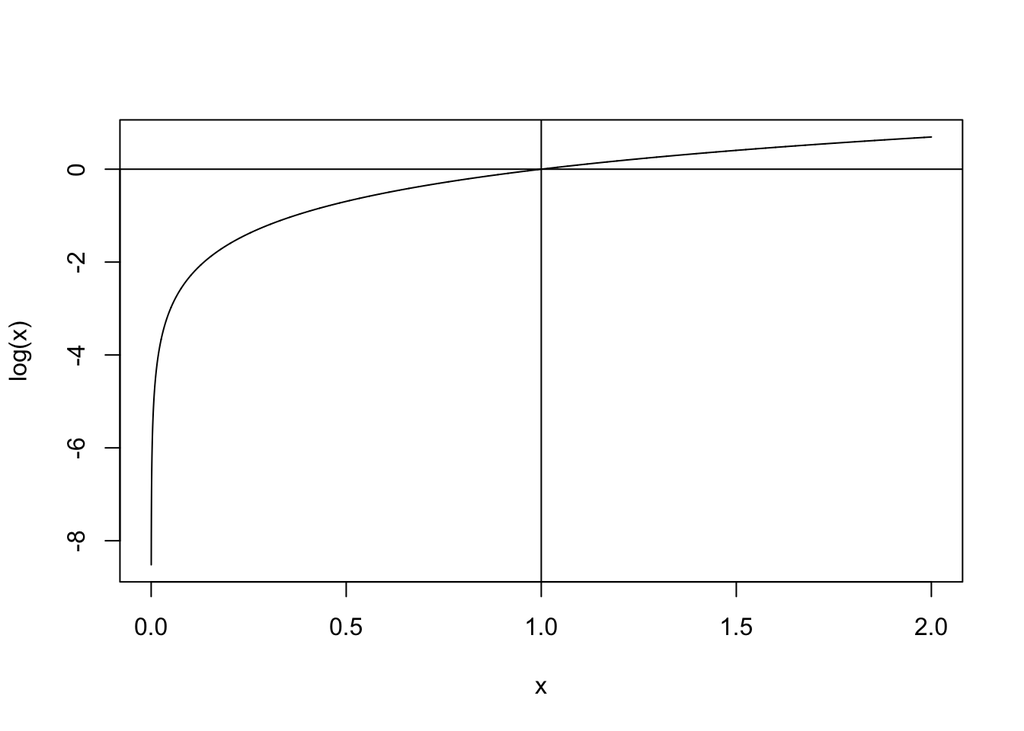

```r
curve(log(x),0,2,10000)
abline(h=0)
abline(v=1)
```

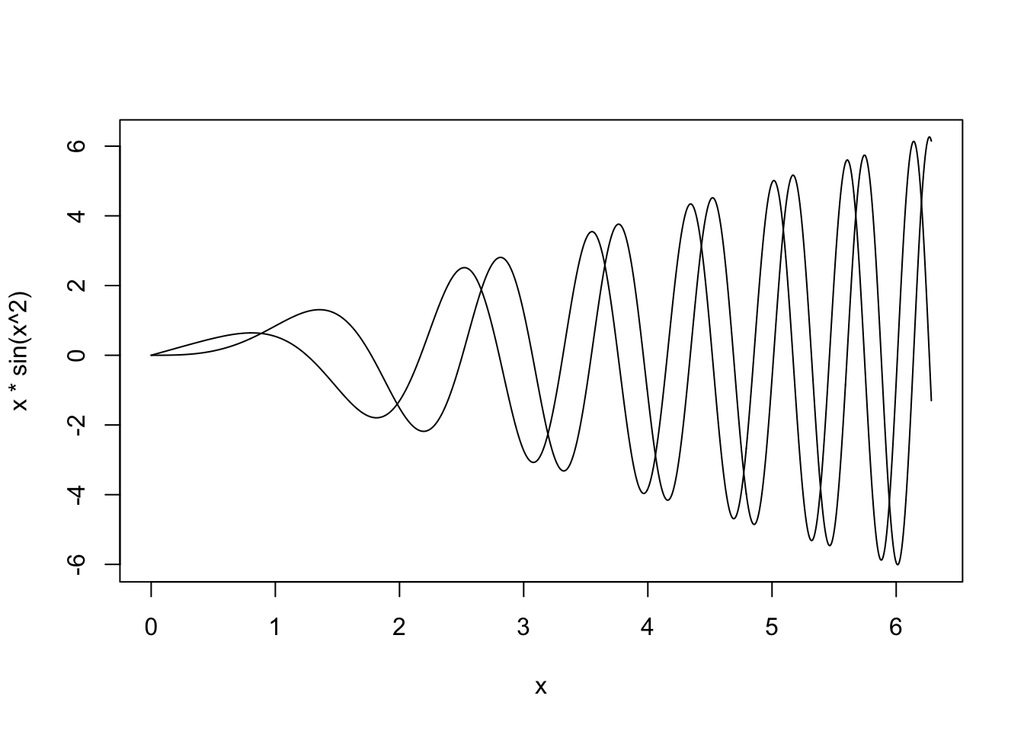

```r
curve(x*sin(x^2),0,2*pi,1000)
curve(x*cos(x^2),0,2*pi,1000,add = TRUE)
```

opgave 1.27

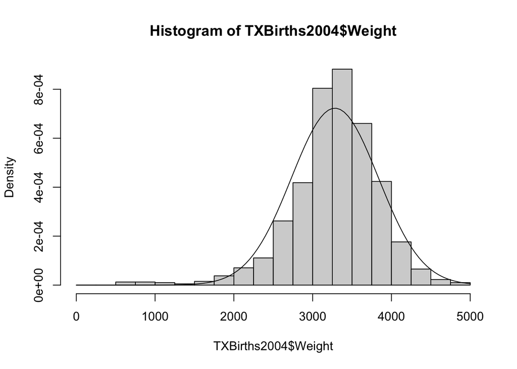

```r
data <-TXBirths2004
hist(TXBirths2004$Weight, freq= FALSE, breaks=250*0:20)


curve(dnorm(x,mean=mean(TXBirths2004$Weight),sd=sd(TXBirths2004$Weight)),0,5000, add=TRUE)
```

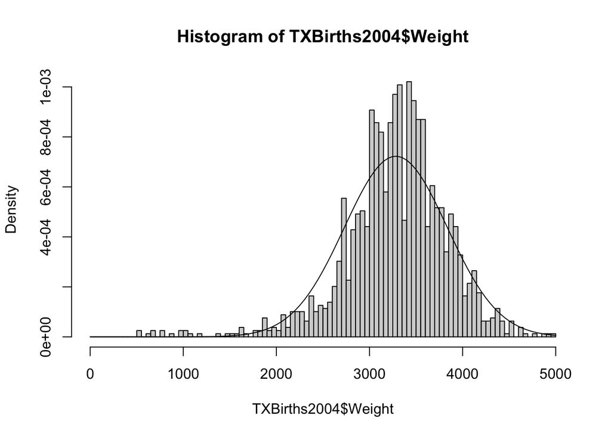

```r
hist(TXBirths2004$Weight, freq= FALSE, breaks=50*0:100)
curve(dnorm(x,mean=mean(TXBirths2004$Weight),sd=sd(TXBirths2004$Weight)),0,5000, add=TRUE)
```

histogrammet bliver langt mindre overskueligt og mere flimret og derved sværere at konkludere ud fra }

oms opgave 1.25 part a)

$$\hat{F}_n(x)=\dfrac{1}{n}*\sum_{i=1}^n\mathbb{1}_{]-\infty,x]}(X_i)$$

vi noterer at:
$$\mathbb{1}_{]-\infty,x]}(X_i)=1\Leftrightarrow
X_i\leq x$$
og
$$\mathbb{1}_{]-\infty,x]}(X_i)=0\Leftrightarrow
X_i> x$$
da er denne transformation bernulli med sandylingheds paramete
$$\mathbb{P}(X_i \leq
x)=F(x)$$
summen af i.i.d bernulli er binomial
$$n*\hat{F}_n(x)=\sum_{i=1}^n\mathbb{1}_{]-\infty,x]}(X_i)$$
er da binomial

del b)

$$\mathbb{E}[\hat{F}_n(x)]=\dfrac{1}{n}*\mathbb{E}[n*\hat{F}_n(x)]=F(x)$$

$$\mathbb{V}[\hat{F}_n(x)]=\dfrac{1}{n^2}*\mathbb{V}[n*\hat{F}_n(x)]=\dfrac{1}{n^2}*n*F(x)*[1-F(x)]$$

$$=\dfrac{1}{n}*F(x)*(1-F(x))$$

del c) vis

$$\lim_{n\to \infty}\mathbb{P}(\lvert
\hat{F}_n(x)-F(x)\lvert \geq \delta)=0 \quad
\forall \delta>0$$

vi bemærker at
$$\hat{F}_n(x)=\dfrac{1}{n}*\sum_{i=1}^n\mathbb{1}_{]-\infty,x]}(X_i)$$
er en stikprøvemiddelværdi for varablen vi allerede har beskrevet som bernulli da siger store tals lov
$$\overline
X \to^{\mathbb{P}} \mu \quad for\,\, n\to\infty$$

da
$$\hat{F}_n(x)$$
er en stkprøve middelværdi for bernulli må:
$$\hat{F}_n(x)
\to^{\mathbb{P}}F(x) \quad for\,\, n\to\infty$$